# hw7_FHChang

Feng-Hsun Chang

2016.Nov.17

To calculate the agreement between observation and predicted probability, calculate the sum of square between observation and predicted probability.

In each loop, I first calculate the moments of both binomial ($n$ and $p$) and beta-binomial distribution($p$ and $\theta$) from the observation. I then used these estimated parameters to predict the probability of number of seeds being predated.

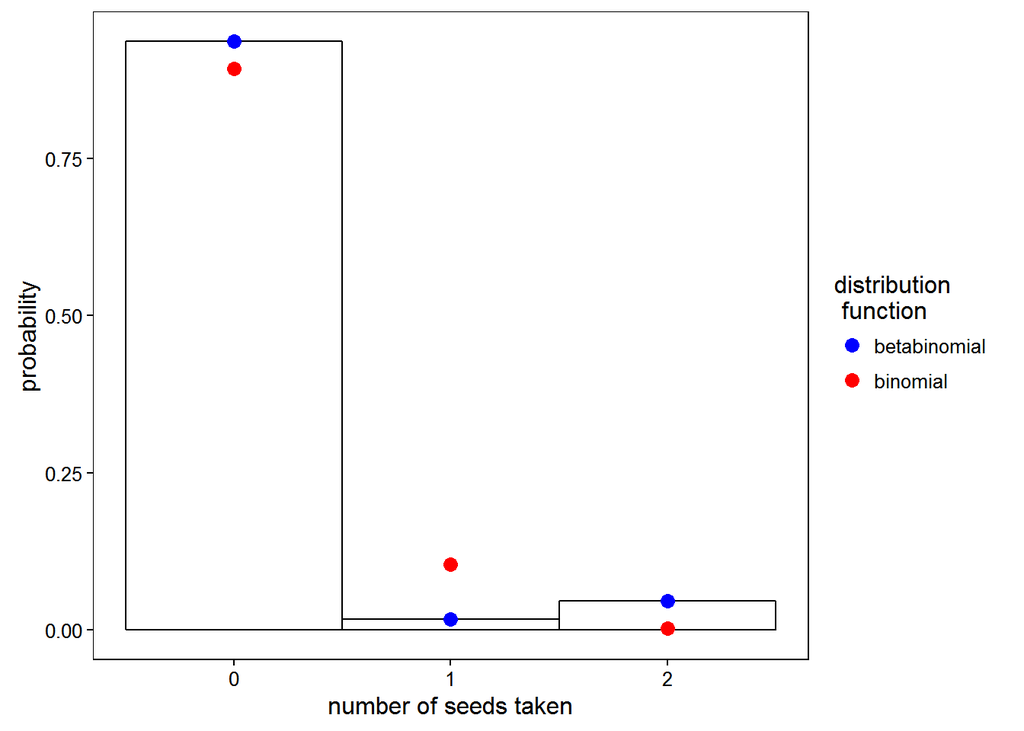

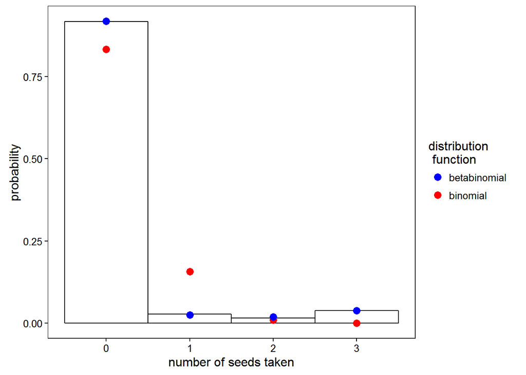

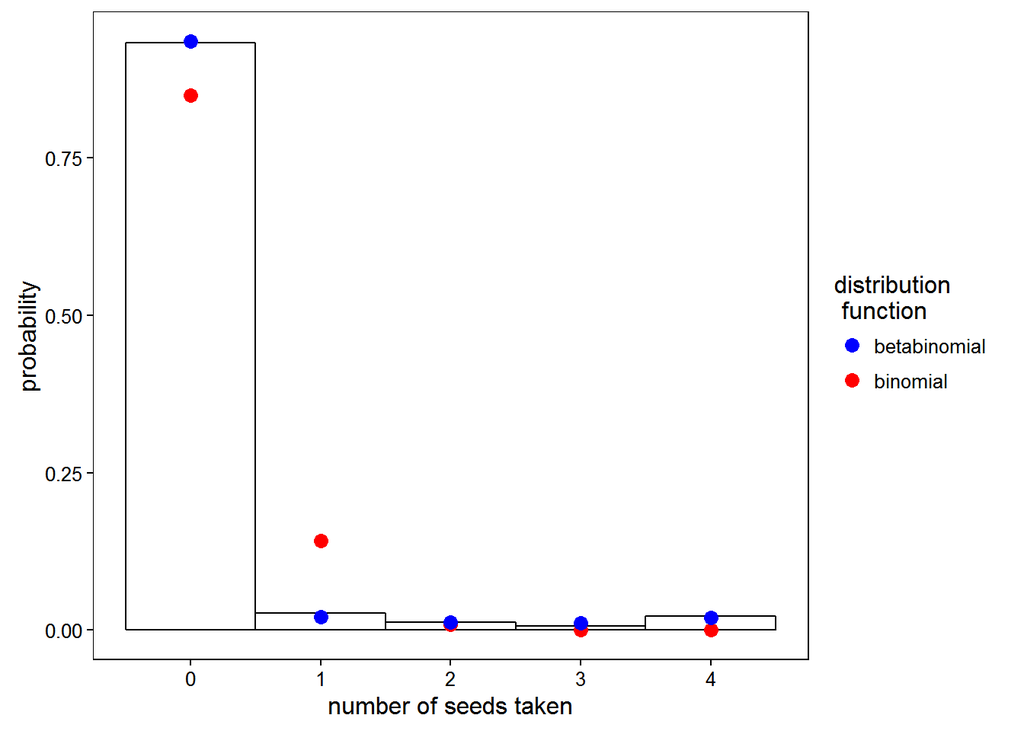

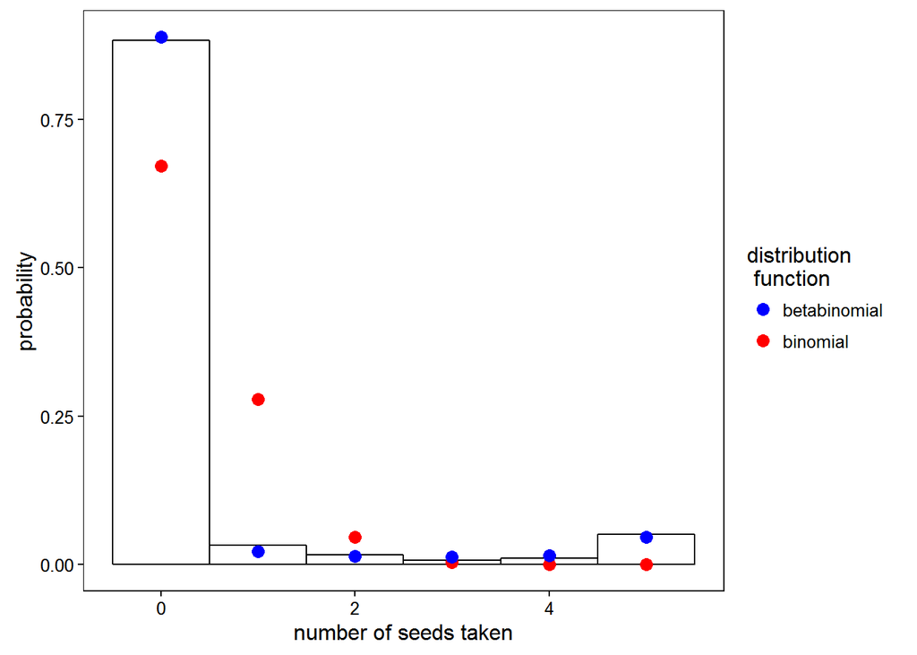

```r
library(magrittr)
library(plyr)
library(ggplot2)
library(emdbook)
library(reshape2)

seeds = read.csv("http://kinglab.eeb.lsa.umich.edu/480/data/seedpred.csv",
         comment.char="#",
         colClasses=c(date="Date",station='factor',
                      dist='factor',species='factor')) %>%
  arrange(station,dist,species,date)

seeds %>%
  ddply(~station+dist+species,summarize,
        avail=head(seeds,-1),
        taken=-diff(seeds),
        tint=diff(date)) %>%
  subset(avail>0) -> dat

moms.binom.all = c()
moms.bb.all = c()
pdf.all = c()
error.all = c()

for (i in 2:5){
  subseeds = subset(dat,avail==i)
  pl = ggplot(data=subseeds,mapping=aes(x=taken))+
    geom_histogram(binwidth=1,fill=NA,color='black',
                   mapping=aes(y=..density..))

  moms.binom = subseeds %>% summarize(n=unique(avail),p=mean(taken)/n)
    ## calculate the moments of binomial distribution, which are the number of seed (n) the probability of seed predation (p)
  moms.binom.all = rbind(moms.binom.all, moms.binom)
    ## store the moments of binomial distribution to a data frame, "moms.binom.all"
  pdf = data.frame(x=seq(0,i)) %>%
    mutate(binom=dbinom(x=x,prob=moms.binom$p,size=moms.binom$n))
    ## claculate the probability of certain number of seeds being predated according to a binomial distribution with parameters ("n" and "p") estimated from the observation.

  moms.bb = subseeds %>%
    summarize(n=unique(avail),m=mean(taken),v=var(taken),
              p=m/n,theta=-n*(v-m*(n-m))/(n*v-m*(n-m)))
    ## calculate hte moments of beta-binomial distribution, which are the probability (p) and dispersion parameter (theta)
  moms.bb.all = rbind(moms.bb.all, moms.bb)
    ## store the moments of beta-binomial distribution to a data frame, "moms.bb.all"
  pdf = pdf %>% mutate(betabinom=dbetabinom(x=x,size=moms.bb$n,prob=moms.bb$p,theta=moms.bb$theta),
                  obs = count(subseeds, vars = "taken")[,2]/nrow(subseeds))
    ## claculate the probability of certain number of seeds being predated according to a beta-binomial distribution with parameters ("p" and "theta") estimated from the observation.
    ## Also calculate the observed probability of seed predation
  pdf.l = pdf %>% melt(id.var=c("x"), variable.name="fun", value.name="den")
    ## preparing long data form for figure
  pdf.all = rbind(pdf.all, pdf)
    ## combine all the probabilities together

  p.final = pl+
    geom_point(data = pdf.l[which(pdf.l$fun!="obs"),], aes(x=x, y=den, group=fun, color=factor(fun)), size=3)+
    scale_colour_manual(name="distribution \n function",
                        breaks=c("betabinom", "binom"),
                        labels=c("betabinomial", "binomial"),
                        values=c("red","blue"))+
    labs(x="number of seeds taken", y="probability")+
    theme_bw()+
    theme(panel.grid.major=element_blank(),
          panel.grid.minor=element_blank(),
          strip.background = element_blank(),
          panel.border=element_rect(color="black"),
          legend.key = element_blank())
  print(p.final)

  error = pdf %>%
    summarize(ebinom = sqrt(sum((binom-obs)^2)), ebb = sqrt(sum((betabinom-obs)^2)))
    ## Here I calculate the sum of square of observe versus predicted probability as a way to demonstrate the agreement between data and prediction.
  error.all = rbind(error.all, error)
    ## I store the sum of square of the two model distributions, so that in the end I can see how the agreement change with number of seeds available.
}
```

These plots are the visualization of observation versus predicted probability in different seed number availability. The observation and predicted probability, I use the histogram is the observation, red dots are the prediction from binomial distribution, blue dots are the prediction from beta-binomial distribution.